## INTRODUCTION

Assessing the value of energy efficiency improvements can be challenging as there’s no way to truly know how much energy a building would have used without the improvements. The best we can do is to build counterfactual models. Once a building is overhauled the new (lower) energy consumption is compared against modeled values for the original building to calculate the savings from the retrofit. More accurate models could support better market incentives and enable lower cost financing.

This competition challenges you to build these counterfactual models across four energy types based on historic usage rates and observed weather. The dataset includes three years of hourly meter readings from over one thousand buildings at several different sites around the world.

## Exploratory Analysis

During this first fase of the project a exploration of the data provided will be carried out. Some elementary questions are expected to be answered during this process: * Which is the data are we facing with? * Does it have missing values or outliers that needed to be treated? * Which seemed to be the correlation between variables? * Which new features can be relevant for the case?

### Setup the software

ggplot2 styles: https://www.datanovia.com/en/blog/the-a-z-of-rcolorbrewer-palette/#install-and-load-rcolorbrewer-package https://www.datanovia.com/en/blog/ggplot-legend-title-position-and-labels/#change-legend-title

The software used for the development of the study and the writing of the report is RStudio [2]. The first step is to define the work directory and to load the libraries: readr[3], dplyr[4], miscTools[5], ggplot2 [6], reshape2[7], ggpubr[8].

```r
#Set Libraries:
library("readr")
library("dplyr")
library("miscTools")
library ("ggplot2")
library("lubridate")
library("tibble")
library("scales")
library("RColorBrewer")
library("reshape2")
```

## Data

5 datasets are provided to explore and create a model to solve this competition. A sixth one is given as a sample submission. They will be explored one by one.

### Train.csv:

This is the main dataset. Some introductory information about the variables is already given:

There are 4 variables in the train data * *building_id*: Unique identification of the buildings, foreign key belonging to the building metadata. * *meter*: id code of the meter. There are 4 types {0: electricity, 1: chilledwater, 2: steam, 3: hotwater}. Not every building has all meter types. * *timestamp*: Datetime where the measurament was taken. * *meter_reading*: This is the target variable. Energy consumption in kWh (or equivalent).

```r
#load the data:
library(readr)
train <- read_csv("data/train.csv")
```

```r
set.seed(2)
selected_id <- sample(unique(train$building_id),350, replace=FALSE)
train <- train[train$building_id %in% selected_id,]
```

We can have some general information about our data set:

```r
str(train)
```

```
## Classes 'tbl_df', 'tbl' and 'data.frame':    4915844 obs. of  4 variables:
##  $ building_id  : num  9 14 15 16 17 19 20 21 25 31 ...
##  $ meter        : num  0 0 0 0 0 0 0 0 0 0 ...
##  $ timestamp    : POSIXct, format: "2016-01-01 00:00:00" "2016-01-01 00:00:00" ...
##  $ meter_reading: num  0 0 0 0 0 0 0 0 0 0 ...
```

```r
summary(train)
```

```
##   building_id         meter          timestamp
##  Min.   :   9.0   Min.   :0.0000   Min.   :2016-01-01 00:00:00
##  1st Qu.: 274.0   1st Qu.:0.0000   1st Qu.:2016-04-06 09:00:00
##  Median : 845.0   Median :0.0000   Median :2016-07-05 03:00:00
##  Mean   : 757.8   Mean   :0.6603   Mean   :2016-07-04 05:40:36
##  3rd Qu.:1171.0   3rd Qu.:1.0000   3rd Qu.:2016-10-03 02:00:00
##  Max.   :1448.0   Max.   :3.0000   Max.   :2016-12-31 23:00:00
##  meter_reading
##  Min.   :       0
##  1st Qu.:      17
##  Median :      77
##  Mean   :    7348
##  3rd Qu.:     269
##  Max.   :21904700
```

```r
nrow(train)
```

```
## [1] 4915844
```

```r
#Number of unique ID in the dataset:
uniqueID<-(unique(train["building_id"]))
nrow(uniqueID)
```

```
## [1] 350
```

```r
#Types of meter for each building
#Create an empty table and add the unique building IDs
types_of_meter <- data.frame(matrix(ncol = 5, nrow =nrow(uniqueID[1])))
x <- c("building_id", "0", "1","2","3")
colnames(types_of_meter) <- x
types_of_meter["building_id"] <-uniqueID[1]

#Iterate among the unique building IDs an select their unique meters:
for (i in uniqueID$building_id) {
  selected_building_meters <- train %>% filter(building_id == i)
  unique_meters <-unique(selected_building_meters$meter)%>% sort()

#Fill the types_of_meter table with the meters that each building have:
  for(j in 0:3){
    if(max(unique_meters==j)== 0){
       types_of_meter[types_of_meter$building_id== i, as.character(j)] = FALSE
    }else{types_of_meter[types_of_meter$building_id== i, as.character(j)] = TRUE}
  }
}

#Change the column names:
colnames(types_of_meter) <- c("building_id","electricity","chilledwater","steam","hotwater")

#Create a graph with the count of each meter:
total_meter <- summarise(types_of_meter, sum_electricity= sum(electricity), sum_chilledwater=sum(chilledwater), sum_steam=sum(steam), sum_hotwater=sum(hotwater))
total_meter <-data.frame(t(total_meter)) %>% rownames_to_column("meter")
colnames(total_meter)<- c("Meter","Count")

#Add the percentages:
total_meter$percentage <- NA

for(i in 1:4){
  total_meter[i,3] <- percent(total_meter[i,2]/nrow(uniqueID),1)
}
```

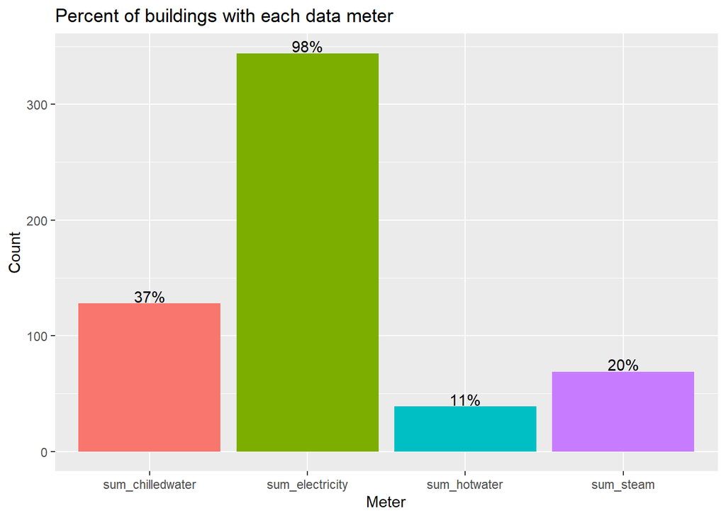

```r
#plot the results:
ggplot(total_meter,aes(Meter,Count)) +
    geom_col(position = 'dodge', aes(fill = Meter)) +
    geom_text(aes(label=percentage), vjust=-0.1) +
    theme(legend.position = "none") +
    labs(title="Percent of buildings with each data meter") +
    scale_color_brewer(palette = "Dark2")
```

From this dataset we can still get more relevant information. Distribution of the meter reading electricity:

```r
#Change the name of the meter to make it more readable and understandable:
train$meter <- plyr::mapvalues(train$meter, from = c(0, 1, 2, 3), to = c("electricity", "chilledwater", "steam", "hotwater"))
```

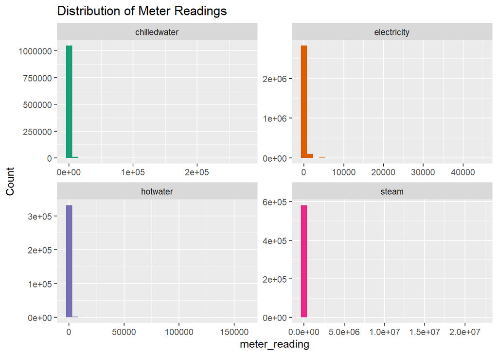

```r
#Plot:
 train %>% group_by(meter)%>%
  ggplot(aes(meter_reading)) +
  geom_histogram() +
  theme(legend.position = "none") +
  ylab("Count") +
  ggtitle("Distribution of Meter Readings") +
  facet_wrap(~ meter, scales = "free") +
  aes(fill= as.factor(meter)) +
  scale_fill_manual(values = c("#1B9E77","#D95F02","#7570B3","#E7298A"))
```

log_10(100) = 2. logaritma en base 10 de 100. a quin numero s’ha d’elevar 10 per tal que doni 100. 10^2 = 100

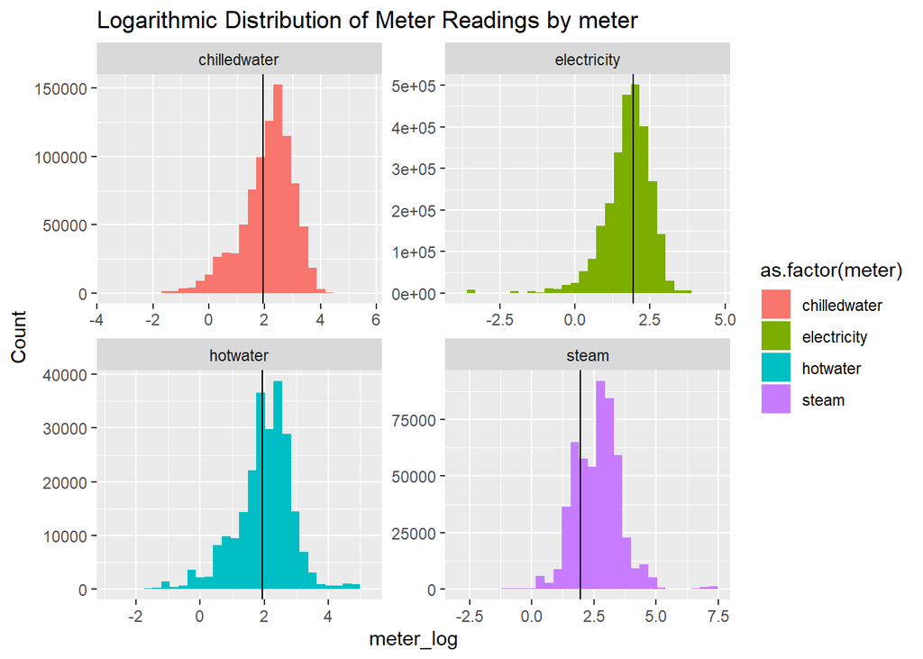

```r
#Create a new variable with the log of the meter reading:
train["meter_log"] <- log(train["meter_reading"],10)

#Plot the new variable:
train[!is.infinite(train$meter_log),] %>% group_by(meter)%>%
  ggplot(aes(meter_log)) +
  geom_histogram(aes(fill= as.factor(meter))) +
  ylab("Count") +
  ggtitle("Logarithmic Distribution of Meter Readings by meter") +
  geom_vline(xintercept = mean(train[!is.infinite(train$meter_log),]$meter_log, na.rm = T)) +
  facet_wrap(~ meter, scales = "free") +
  scale_color_brewer(palette = "Dark2")
```

falta afegir testos de normalitat amb i sense outliers.

- Distribution of the average meter reading throught the year:

```r
train  <- train %>% mutate(timestamp_date = ymd(gsub( " .*$", "", timestamp)),
                          timestamp_month = month(timestamp_date),
                          timestamp_day = wday(timestamp_date, label = T, abbr = T),
                          timestamp_day_number = day(timestamp_date),
                          time_ymd_hms = ymd_hms(timestamp),
                          time_hour = hour(time_ymd_hms))
```

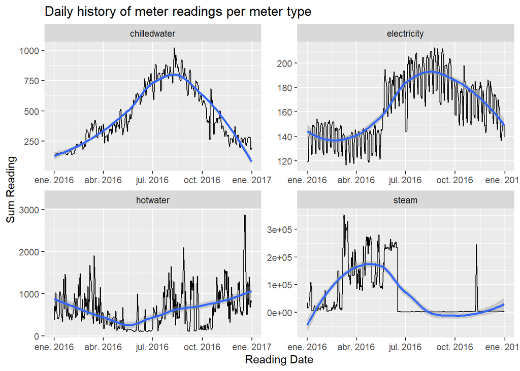

```r
# Plot the daily aggregates per each meter type. MEAN to understand how they change, Median to smooth and remove the outliers.
train %>%
  group_by(meter, timestamp_date) %>%
  summarise(sum_reading = mean(meter_reading, na.rm = T)) %>%
  ggplot(aes(x= timestamp_date, y= sum_reading)) +
  geom_line() +
  geom_smooth(se = T) +
  facet_wrap(~meter, scales = "free") +
  ggtitle("Daily history of meter readings per meter type") +
  labs(x= "Reading Date", y= "Sum Reading")
```

Electricity es el mes estable amb menys outliers, mentres que els altres tres en tenen mes.

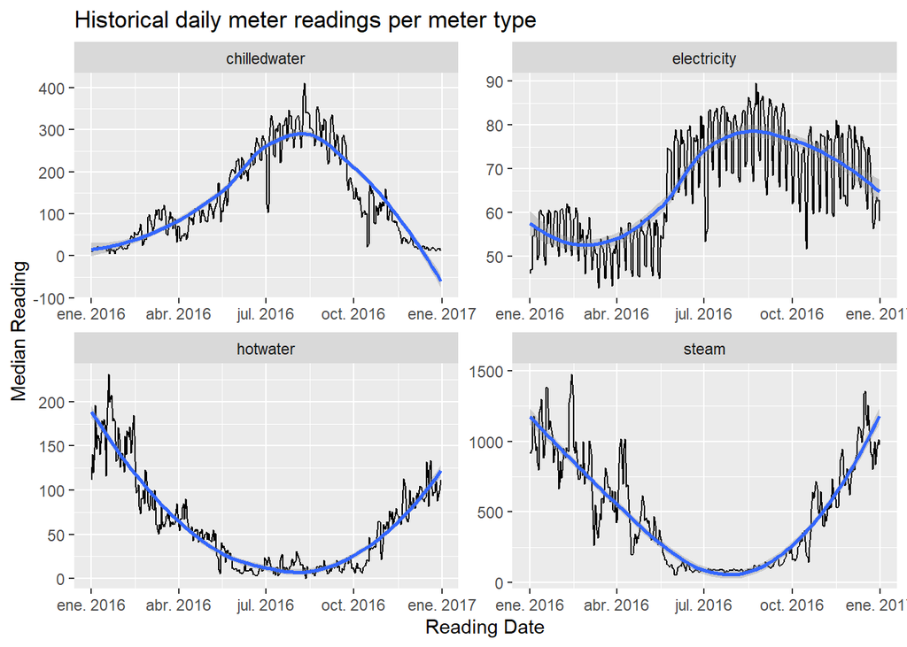

```r
# Plot the daily aggregates per each meter type. MEDIAN to understand how they change, Median to smooth and remove the outliers.
train %>%
  group_by(meter, timestamp_date) %>%
  summarise(median_reading = median(meter_reading, na.rm = T)) %>%
  ggplot(aes(x= timestamp_date, y= median_reading)) +
  geom_line() +
  geom_smooth(se = T) +
  facet_wrap(~meter, scales = "free") +
  ggtitle("Historical daily meter readings per meter type") +
  labs(x= "Reading Date", y= "Median Reading")
```

Et dona una idea la mediana de com varia el consum tipic. Es el punt mig de totes les mesures durant el dia. Es molt robusta a outliers. ###### buscar un cita que demostri que la mediana es robusta a outliers Veiem clarament que hi ha molta variabilitat i que el tipus de industria influeix molt. Per tant fem el merge amb la taula dels buildings i comencem a treballar amb ella

```r
building_metadata <- read_csv("data/building_metadata.csv")
str(building_metadata)
```

```
## Classes 'spec_tbl_df', 'tbl_df', 'tbl' and 'data.frame': 1449 obs. of  6 variables:
##  $ site_id    : num  0 0 0 0 0 0 0 0 0 0 ...
##  $ building_id: num  0 1 2 3 4 5 6 7 8 9 ...
##  $ primary_use: chr  "Education" "Education" "Education" "Education" ...
##  $ square_feet: num  7432 2720 5376 23685 116607 ...
##  $ year_built : num  2008 2004 1991 2002 1975 ...
##  $ floor_count: num  NA NA NA NA NA NA NA NA NA NA ...
##  - attr(*, "spec")=
##   .. cols(
##   ..   site_id = col_double(),
##   ..   building_id = col_double(),
##   ..   primary_use = col_character(),
##   ..   square_feet = col_double(),
##   ..   year_built = col_double(),
##   ..   floor_count = col_double()
##   .. )
```

- *site_id* - Foreign key for the weather files.
- *building_id* - Foreign key for training.csv
- *primary_use* - Indicator of the primary category of activities for the building based on EnergyStar property type definitions
- *square_feet* - Gross floor area of the building
- *year_built* - Year building was opened
- *floor_count* - Number of floors of the building

```r
summary(building_metadata)
```

```
##     site_id        building_id   primary_use         square_feet
##  Min.   : 0.000   Min.   :   0   Length:1449        Min.   :   283
##  1st Qu.: 3.000   1st Qu.: 362   Class :character   1st Qu.: 23012
##  Median : 5.000   Median : 724   Mode  :character   Median : 57673
##  Mean   : 6.952   Mean   : 724                      Mean   : 92112
##  3rd Qu.:13.000   3rd Qu.:1086                      3rd Qu.:115676
##  Max.   :15.000   Max.   :1448                      Max.   :875000
##
##    year_built    floor_count
##  Min.   :1900   Min.   : 1.000
##  1st Qu.:1949   1st Qu.: 1.000
##  Median :1970   Median : 3.000
##  Mean   :1968   Mean   : 3.741
##  3rd Qu.:1995   3rd Qu.: 5.000
##  Max.   :2017   Max.   :26.000
##  NA's   :774    NA's   :1094
```

Switch from feets to meters for better understanding

```r
building_metadata$square_meters <- building_metadata$square_feet * 0.0929030
```

Estudi de les diferents variables del dataset: -Primary use building:

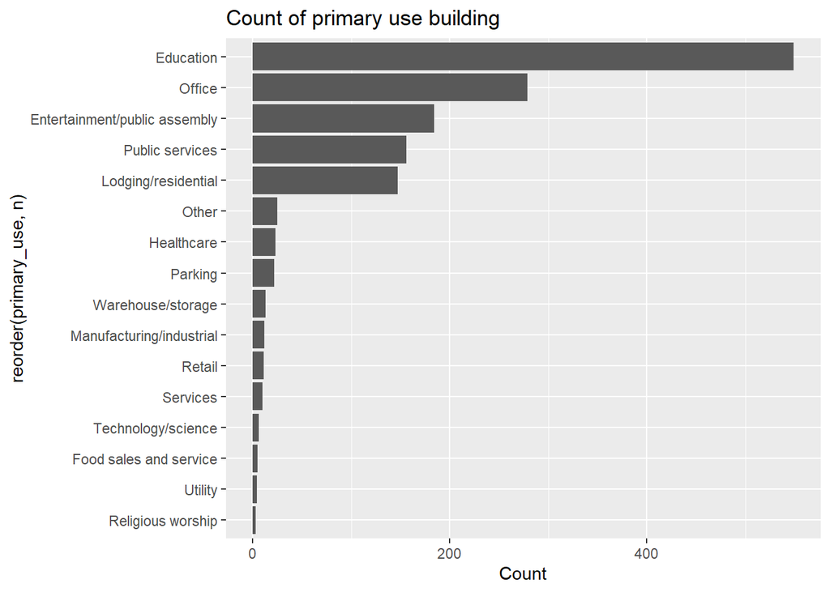

```r
building_metadata %>% count(primary_use)%>%
  ggplot(aes(x= reorder(primary_use, n), y= n)) +
  geom_col() +
  theme(legend.position = "none") +
  ylab("Count") +
  ggtitle("Count of primary use building") +
  coord_flip()
```

```r
df <-building_metadata %>% count(primary_use)%>%arrange(desc(n))%>% mutate(percentage = percent(n/sum(n),1))
df
```

```
## # A tibble: 16 x 3
##    primary_use                       n percentage
##    <chr>                         <int> <chr>
##  1 Education                       549 38%
##  2 Office                          279 19%
##  3 Entertainment/public assembly   184 13%
##  4 Public services                 156 11%
##  5 Lodging/residential             147 10%
##  6 Other                            25 2%
##  7 Healthcare                       23 2%
##  8 Parking                          22 2%
##  9 Warehouse/storage                13 1%
## 10 Manufacturing/industrial         12 1%
## 11 Retail                           11 1%
## 12 Services                         10 1%
## 13 Technology/science                6 0%
## 14 Food sales and service            5 0%
## 15 Utility                           4 0%
## 16 Religious worship                 3 0%
```

El segment on es troben concentrats la majoria d’edificis es en la Educació, oficines, edificis públics i edificis residencials. Aquests formen el 91% dels edificis.

- Size of the building:

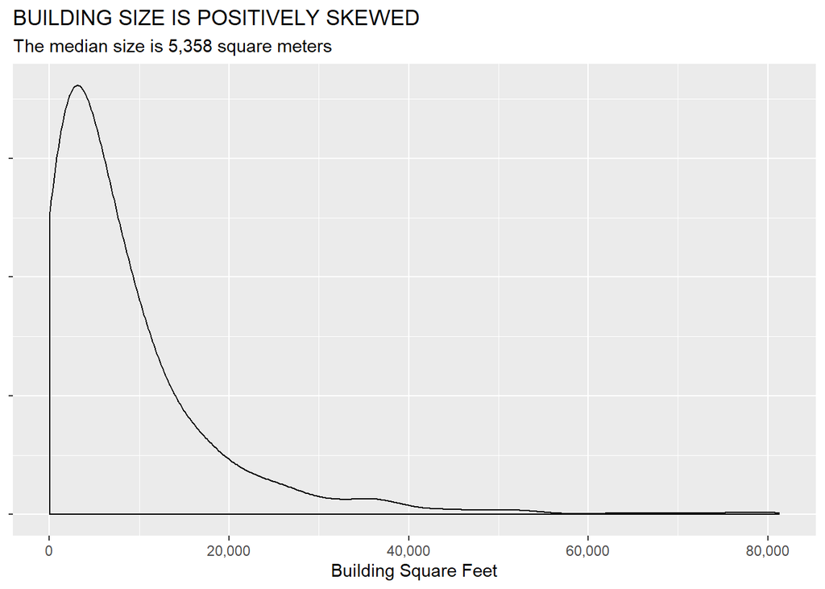

```r
building_metadata %>%
  ggplot(aes(x= square_meters)) +
  geom_density(adjust = 2, alpha = 0.7) +
  scale_x_continuous(labels = comma, name = "Building Square Feet") +
  ggtitle("BUILDING SIZE IS POSITIVELY SKEWED", subtitle = paste0("The median size is ", comma(median(building_metadata$square_meters)), " square meters")) +
  theme(axis.title.y = element_blank(), axis.text.y = element_blank())
```

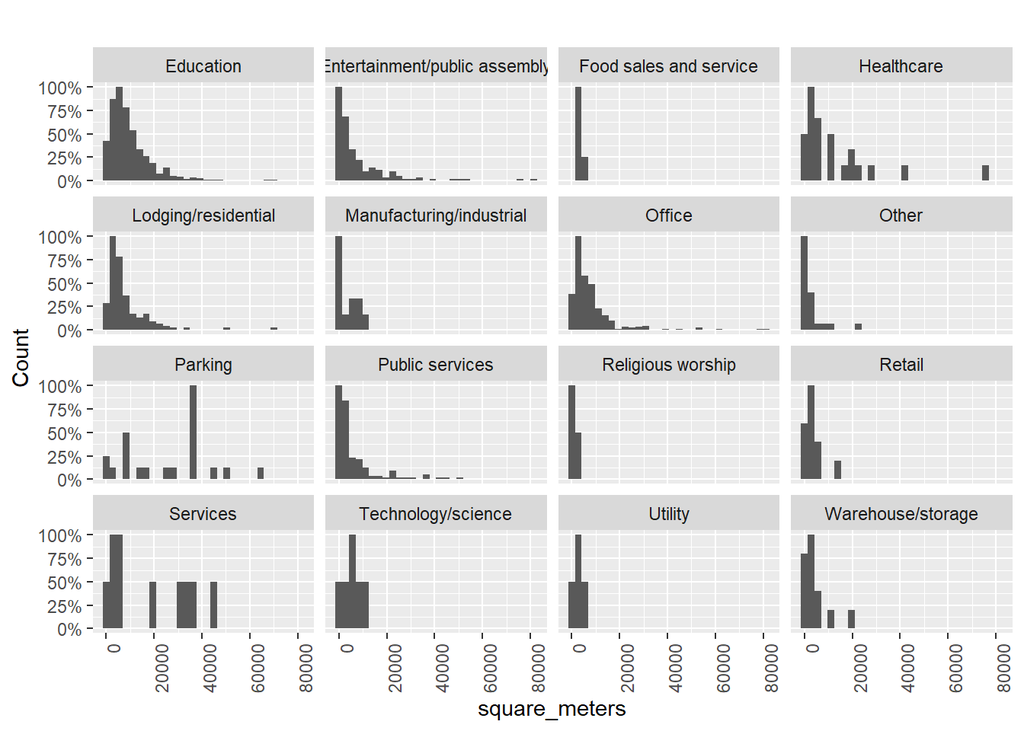

```r
building_metadata%>% group_by(primary_use)%>%
  ggplot(aes(square_meters)) +
  geom_histogram(aes(x = square_meters, y = ..ncount..)) +
  scale_y_continuous(labels = percent_format())+
  ylab("Count") +
  ggtitle("") +
  facet_wrap(~ primary_use) +
  theme(axis.text.x = element_text(angle = 90, hjust = 1))
```

- year built:

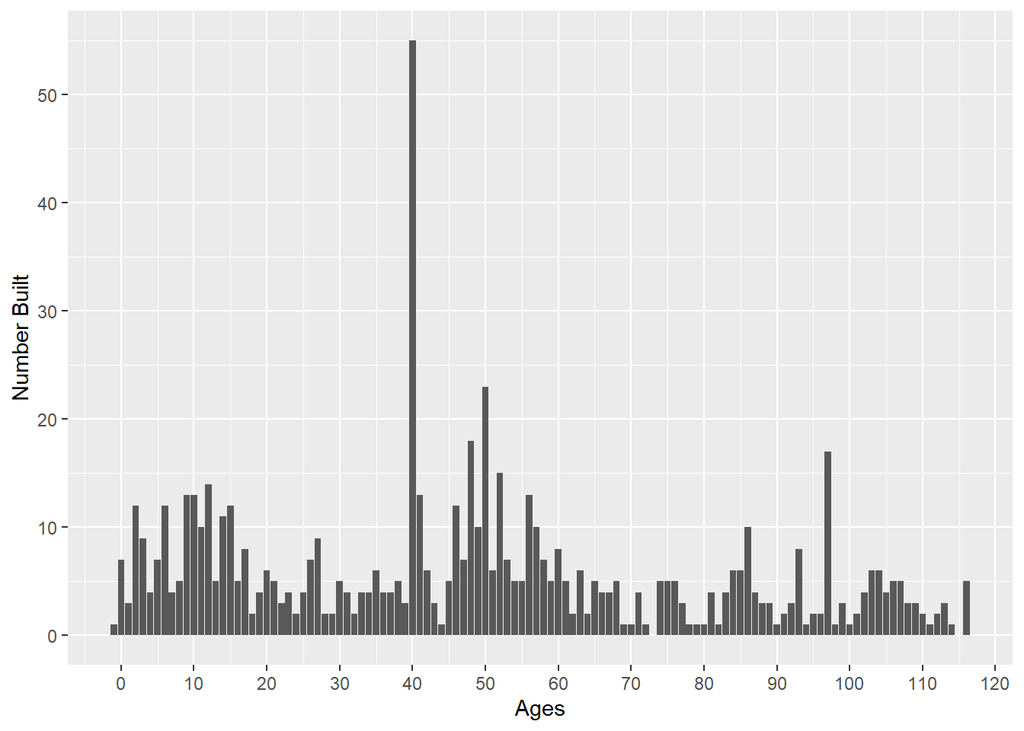

```r
#creem una nova variable que ens calculi en anys quina antiguetat te l'edifici:
building_metadata$age <- 2016 - building_metadata$year_built

building_metadata %>%
  distinct(building_id, .keep_all = T) %>%
  group_by(age) %>%
  summarise(n_buildings = n()) %>%
  ggplot(aes(x= age, y= n_buildings)) +
  geom_col() +
  scale_y_continuous(name = "Number Built", breaks = seq(0,60,10)) +
  scale_x_continuous(name = "Ages", breaks = seq(0,120,10))
```

Segurament l’edat de un edifici serà de alt valor per les prediccions de gasto de energia. https://www.revistaciencia.amc.edu.mx/images/revista/67_4/PDF/VidaUtilEdificios.pdf segons la taula i agafant com a estandard pel tipus de edificis majoritaris la vida util alta. Podem segmentar la edat dels edificis en aquests grups:

```r
building_metadata$ageGroup <- findInterval(building_metadata$age, c(25, 60, 120 ))
building_metadata$ageGroup <- replace(building_metadata$ageGroup, building_metadata$ageGroup == 0, "new" )
building_metadata$ageGroup <- replace(building_metadata$ageGroup, building_metadata$ageGroup == 1, "medium" )
building_metadata$ageGroup <- replace(building_metadata$ageGroup, building_metadata$ageGroup == 2, "old" )
```

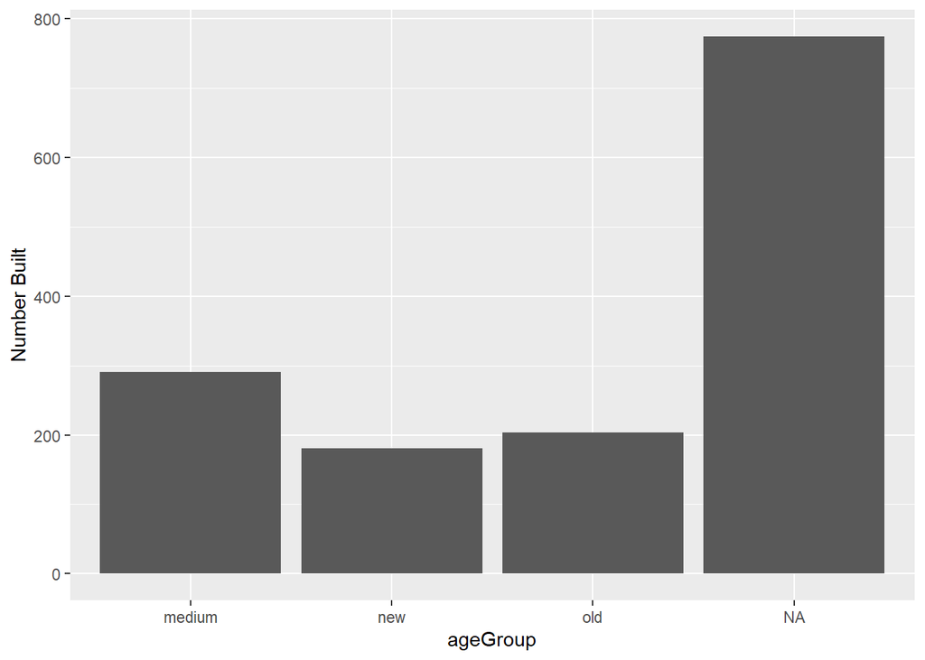

```r
building_metadata %>%
  distinct(building_id, .keep_all = T) %>%
  group_by(ageGroup) %>%
  summarise(n_buildings = n()) %>%
  ggplot(aes(x= ageGroup, y= n_buildings)) +
  geom_col() +
  scale_y_continuous(name = "Number Built")
```

Let’s merge the two datasets

```r
data_train <- merge(train, building_metadata, by='building_id')
```

Correlation between variables:

```r
Corr <- data_train %>% select (meter_reading, floor_count, age, square_feet) %>% na.omit() %>% cor() %>% as.data.frame()

Corr
```

```
##               meter_reading floor_count        age square_feet
## meter_reading    1.00000000   0.1891891 0.04929546  0.69491228
## floor_count      0.18918914   1.0000000 0.21194187  0.36675918
## age              0.04929546   0.2119419 1.00000000  0.08463744
## square_feet      0.69491228   0.3667592 0.08463744  1.00000000
```

There is a positive correlation between the size (square_feet and floor_count) and the meter reading.The age of the building seems to be less linearly correlated with this.

Let’s see if differences can be found between types of meter:

```r
corrForMeter <- data.frame(row.names = c("meter_reading", "floor_count", "age", "square_feet"))

for (i in (unique(data_train$meter))){
data <- data_train %>% filter(meter == i) %>% select (meter_reading, floor_count, age, square_feet) %>% na.omit() %>% cor() %>% as.data.frame() %>% select(meter_reading)
names(data) <- i
corrForMeter <- cbind(corrForMeter, data)}

corrForMeter
```

```
##               electricity chilledwater hotwater      steam
## meter_reading  1.00000000    1.0000000 1.000000  1.0000000
## floor_count    0.20098047    0.1003777 0.720265  0.1166876
## age            0.04437223   -0.4111323 0.720265 -0.4704664
## square_feet    0.77904047    0.4497704 0.720265  0.5152874
```

WEATHER TRAIN DATASET:

```r
weather_train <- read_csv("data/weather_train.csv")
str(weather_train)
```

```
## Classes 'spec_tbl_df', 'tbl_df', 'tbl' and 'data.frame': 139773 obs. of  9 variables:
##  $ site_id           : num  0 0 0 0 0 0 0 0 0 0 ...
##  $ timestamp         : POSIXct, format: "2016-01-01 00:00:00" "2016-01-01 01:00:00" ...
##  $ air_temperature   : num  25 24.4 22.8 21.1 20 19.4 21.1 21.1 20.6 21.1 ...
##  $ cloud_coverage    : num  6 NA 2 2 2 NA 6 NA NA NA ...
##  $ dew_temperature   : num  20 21.1 21.1 20.6 20 19.4 21.1 21.1 20 20.6 ...
##  $ precip_depth_1_hr : num  NA -1 0 0 -1 0 -1 0 0 0 ...
##  $ sea_level_pressure: num  1020 1020 1020 1020 1020 ...
##  $ wind_direction    : num  0 70 0 0 250 0 0 210 0 290 ...
##  $ wind_speed        : num  0 1.5 0 0 2.6 0 0 1.5 0 1.5 ...
##  - attr(*, "spec")=
##   .. cols(
##   ..   site_id = col_double(),
##   ..   timestamp = col_datetime(format = ""),
##   ..   air_temperature = col_double(),
##   ..   cloud_coverage = col_double(),
##   ..   dew_temperature = col_double(),
##   ..   precip_depth_1_hr = col_double(),
##   ..   sea_level_pressure = col_double(),
##   ..   wind_direction = col_double(),
##   ..   wind_speed = col_double()
##   .. )
```

Weather data from a meteorological station as close as possible to the site.

site_id air_temperature - Degrees Celsius cloud_coverage - Portion of the sky covered in clouds, in oktas dew_temperature - Degrees Celsius precip_depth_1_hr - Millimeters sea_level_pressure - Millibar/hectopascals wind_direction - Compass direction (0-360) wind_speed - Meters per second

```r
summary(weather_train)
```

```
##     site_id         timestamp                   air_temperature
##  Min.   : 0.000   Min.   :2016-01-01 00:00:00   Min.   :-28.90
##  1st Qu.: 3.000   1st Qu.:2016-04-02 02:00:00   1st Qu.:  7.20
##  Median : 7.000   Median :2016-07-02 09:00:00   Median : 15.00
##  Mean   : 7.479   Mean   :2016-07-02 07:17:57   Mean   : 14.42
##  3rd Qu.:11.000   3rd Qu.:2016-10-01 16:00:00   3rd Qu.: 22.20
##  Max.   :15.000   Max.   :2016-12-31 23:00:00   Max.   : 47.20
##                                                 NA's   :55
##  cloud_coverage  dew_temperature  precip_depth_1_hr sea_level_pressure
##  Min.   :0.00    Min.   :-35.00   Min.   : -1.00    Min.   : 968.2
##  1st Qu.:0.00    1st Qu.:  0.60   1st Qu.:  0.00    1st Qu.:1011.8
##  Median :2.00    Median :  8.30   Median :  0.00    Median :1016.4
##  Mean   :2.15    Mean   :  7.35   Mean   :  0.98    Mean   :1016.2
##  3rd Qu.:4.00    3rd Qu.: 14.40   3rd Qu.:  0.00    3rd Qu.:1020.8
##  Max.   :9.00    Max.   : 26.10   Max.   :343.00    Max.   :1045.5
##  NA's   :69173   NA's   :113      NA's   :50289     NA's   :10618
##  wind_direction    wind_speed
##  Min.   :  0.0   Min.   : 0.000
##  1st Qu.: 80.0   1st Qu.: 2.100
##  Median :190.0   Median : 3.100
##  Mean   :180.5   Mean   : 3.561
##  3rd Qu.:280.0   3rd Qu.: 5.000
##  Max.   :360.0   Max.   :19.000
##  NA's   :6268    NA's   :304
```

In this data set there is some missing data that can be pretty relevant in terms of the prediction of the consumption.